# A Little More Hypothesis Testing

# Alternative Hypotheses

## What Happens If We Reject?

Consider the null hypothesis $H_0: p = p_0$.

If we get a $p$-value below our significance level, we reject $H_0$.

In this case, we know that $p \neq p_0$.

This conclusion is called the *alternative hypothesis*.

We denote this: $H_A: p \neq p_0$.

## Other Alternatives

Sometimes, we are only interested in *one-sided* alternatives.

If we are testing a blood pressure medication, we want evidence that the medicine *lowers* blood pressure.

If $\mu_1$ and $\mu_2$ are mean blood pressure in people who do and do not take the medication, then:

- The null hypothesis is $H_0: \mu_1 = \mu_2$.
- The alternative hypothesis of interest is $H_A:\mu_1 < \mu_2$.

## One-Sided Alternatives

**Example:** We are interested in the number of credit hours taken by Wake undergrads on average.

The minimum for full-time status is 15 credit hours on average. Therefore the null is:

$$H_0: \mu = 15,$$

where $\mu$ is the average number of credit hours taken by all Wake Forest undergrads.

**Discussion Question**

What would be a sensible alternative hypothesis in this case?

## One-Sided Alternatives

**Discussion Question**

What would be a sensible alternative hypothesis in this case?

Because we know the average will be 15 at a minimum, it makes sense to take the alternative to be
$$H_A: \mu > 15,$$
which is a one-sided alternative.

## Testing One-Sided Alternatives

Remember that to test this hypothesis, we will:

1. Find the $t$-score of our estimate, the mean $\overline{x}$
2. Calculate a $p$-value from our $t$-score
3. Compare to the significance level and make a decision

For a two-sided alternative, we reject the null hypothesis when:

- The estimate $\overline{x}$ is too far from $\mu_0$ (in the rejection region)
- The $p$-value is too small (below the significance level)

## Testing One-Sided Alternatives

**Discussion Question**

For what values of the estimate and $p$-value would we reject a null hypothesis with the one-sided alternative $H_A: \mu > 15$?

1. Only values of $\overline{x}$ larger than $\mu_0=15$ are evidence in favor of $H_A$ over $H_0$.
2. Therefore, we should compute the $p$-value using only the *upper* tail value.

## Testing One-Sided Alternatives

$$H_A: \mu \neq 0$$

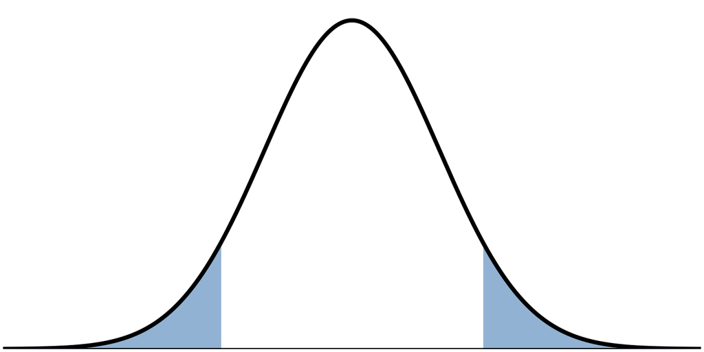

$$H_A: \mu > 0$$

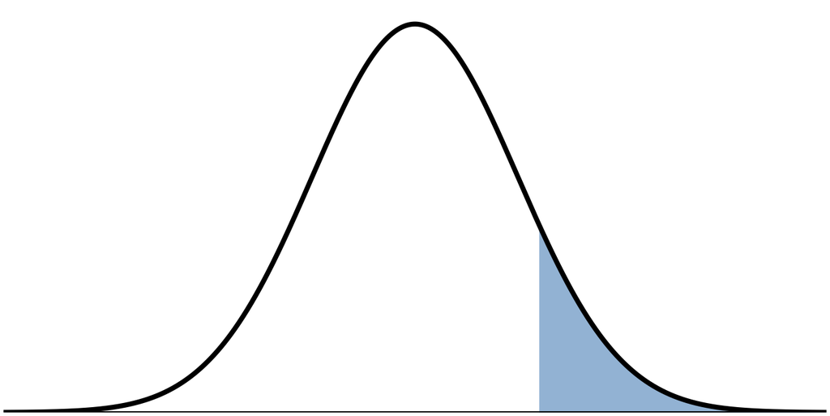

$$H_A: \mu < 0$$

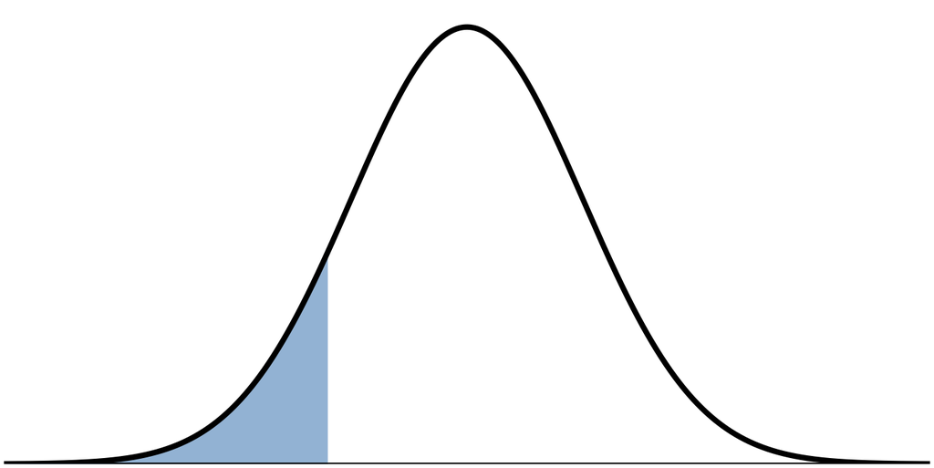

To find a one-sided $p$-value: **Just divide the two-sided $p$-value in half!**

# Revisiting Rejection Regions

## Aside on Vocabulary

We have now seen four types of null hypothesis:
$$H_0: p = p_0, \quad H_0:\mu=\mu_0, \quad H_0: p_1 = p_2,\quad H_0:\mu_1 = \mu_2$$

We call the value that the null hypothesis states the **null value**.

For single quantities, the null values are $p_0$ and $\mu_0$, respectively.

For differences of quantities, the null values are both $0$.

(This is because the null hypothesis states the *difference* is 0.)

## Rejection Regions for Two-Sided Tests

For a two-sided alternative, we compute a rejection region by doing:

1. Compute the estimate of the population quantity.
2. Check that the central limit theorem applies.
3. Choose your significance level, $\alpha$.
4. Find the $\mathrm{SE}$ if $H_0$ is true.
5. Find the critical value $z^*$ or $t^*$ corresponding to $1-\alpha$.
6. Calculate the rejection region: $\text{null value } \pm \text{ critical value}\times\mathrm{SE}$.
7. Reject if estimate is *outside* the rejection region bounds.

## One-Sided Rejection Regions

Consider a one-sided alternative with a $>$ inequality.

Then the steps are:

1. Compute the estimate of the population quantity.
2. Check that the central limit theorem applies.
3. Choose your significance level, $\alpha$.
4. Find the $\mathrm{SE}$ if $H_0$ is true.
5. Find the critical value $z^*$ or $t^*$ corresponding to $\textcolor{blue}{1-2\alpha}$.
6. Calculate the rejection region: $\textcolor{blue}{\text{null value } + \text{ critical value}\times\mathrm{SE}}$.
7. Reject if the estimate is greater than the rejection region bound.

## One-Sided Rejection Regions

$$H_A: \mu \neq 0$$

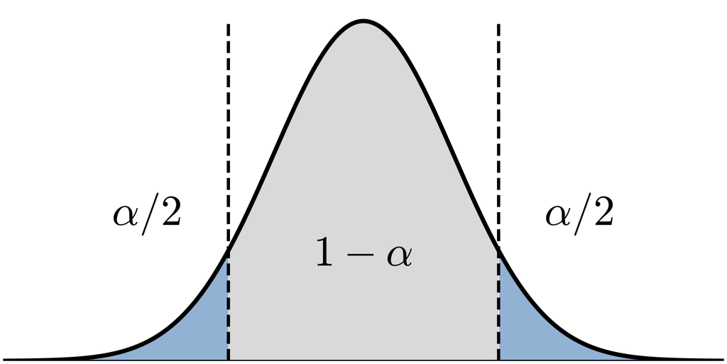

$$H_A: \mu > 0$$

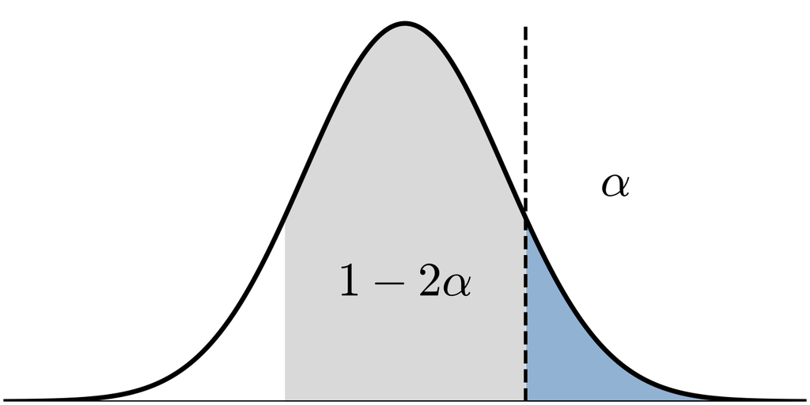

$$H_A: \mu < 0$$

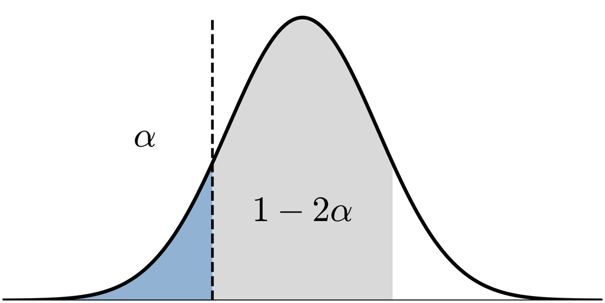

## You Try It

[interactive chart not shown]